# Statistics in Python: Correlation Coefficients

⇦ Back

Let’s use the following example data set which comes from Giavarina (2015)<sup>[1]</sup>. Imagine that a set of objects were each measured twice - once using ‘Method A’ and once using ‘Method B’ - giving the two lists of measurements shown below:

```python
import pandas as pd

df = pd.DataFrame({
    'Method A': [
        1.0, 5.0, 10.0, 20.0, 50.0, 40.0, 50.0, 60.0, 70.0, 80.0, 90.0, 100.0,
        150.0, 200.0, 250.0, 300.0, 350.0, 400.0, 450.0, 500.0, 550.0, 600.0,
        650.0, 700.0, 750.0, 800.0, 850.0, 900.0, 950.0, 1000.0
    ],
    'Method B': [
        8.0, 16.0, 30.0, 24.0, 39.0, 54.0, 40.0, 68.0, 72.0, 62.0, 122.0, 80.0,
        181.0, 259.0, 275.0, 380.0, 320.0, 434.0, 479.0, 587.0, 626.0, 648.0,
        738.0, 766.0, 793.0, 851.0, 871.0, 957.0, 1001.0, 960.0
    ]
})
```

These can be visualised on a scatter plot:

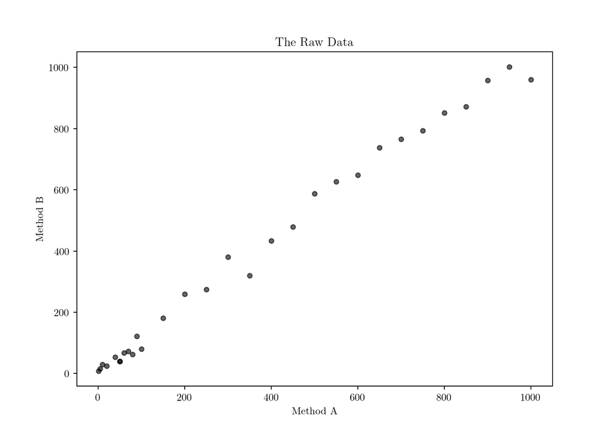

```python
import matplotlib.pyplot as plt

# Options
x = 5  # Want figures to be A5
plt.rc('figure', figsize=[46.82 * .5**(.5 * x), 33.11 * .5**(.5 * x)])
plt.rc('text', usetex=True)
plt.rc('font', family='serif')
plt.rc('text.latex', preamble=r'\usepackage{textgreek}')

# Plot
ax = plt.axes()
ax.set(title='The Raw Data', xlabel='Method A', ylabel='Method B')
# Scatter plot
ax.scatter(df['Method A'], df['Method B'], c='k', s=20, alpha=0.6, marker='o')
# Show
plt.show()
```

These points seem to roughly show a straight-line relationship, but let’s be a bit more precise and start to quantify *exactly* how much they correlate…

# 1 Pearson’s Correlation Coefficient (*r*)

As described on its [Wikipedia page](https://en.wikipedia.org/wiki/Pearson_correlation_coefficient), the Pearson’s *r* statistic measures linear correlation between two variables. It assumes that a set of data points can be approximated by a straight line and returns a value that describes how strong the linear correlation is:

- +1 is total positive linear correlation (the data points all lie on a straight line with a positive gradient)
- 0 is no linear correlation (the data points are randomly scattered all over the plot area)
- −1 is total negative linear correlation (the data points all lie on a straight line with a negative gradient)

For more precise interpretations of the absolute value of *r* the follow can be used as a guideline<sup>[2]</sup>:

- 0 to 0.19: very weak correlation
- 0.2 to 0.39: weak correlation
- 0.4 to 0.59: moderate correlation
- 0.6 to 0.79: strong correlation
- 0.8 to 1: very strong correlation

…and here’s how to calculate it:

```python
from scipy import stats
import numpy as np

# Pearson's r
x = df['Method A']
y = df['Method B']
r, p = stats.pearsonr(x, y)

# Transform the correlation coefficient into a Fishers’ Z-score
r_z = np.arctanh(r)  # These two ways are equivalent
r_z = 0.5 * np.log((1 + r) / (1 - r))  # These two ways are equivalent
# Standard error
se = 1 / np.sqrt(x.size - 3)
# Calculate confidence interval in Z-space
alpha = 0.05  # 95% CI
z = stats.norm.ppf(1 - alpha / 2)
low_z, high_z = r_z - z * se, r_z + z * se
# Transform back into r-space
low, high = np.tanh((low_z, high_z))

print(f'r = {r:5.3f} (CI: {low:5.3f} - {high:5.3f}), p = {p:5.3f}')
```

```
## r = 0.996 (CI: 0.991 - 0.998), p = 0.000
```

This *r* value is close to 1, which confirms that the points nearly follow a straight line. Let’s visualise this by using the *r* statistic to generate a line of best fit:

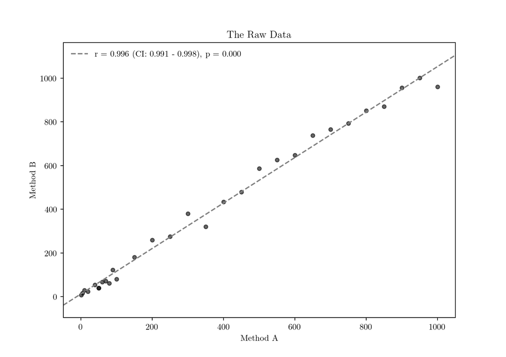

```python
# Line of best fit
r, p = stats.pearsonr(x, y)
# Gradient of line of best-fit
m = r * np.std(y) / np.std(x)
# Y-intercept of line of best-fit
c = np.mean(y) - m * np.mean(x)

# Plot
ax = plt.axes()
ax.set(title='The Raw Data', xlabel='Method A', ylabel='Method B')
# Scatter plot
ax.scatter(df['Method A'], df['Method B'], c='k', s=20, alpha=0.6, marker='o')
# Get axis limits
left, right = plt.xlim()
# Keep current axis limits
ax.set_xlim(left, right)
# Line of best-fit
x = np.array([left, right])
y = m * x + c
ax.plot(
    x, y, c='grey', ls='--',
    label=f'r = {r:5.3f} (CI: {low:5.3f} - {high:5.3f}), p = {p:5.3f}'
)
# Legend
ax.legend(frameon=False)
# Show
plt.show()
```

It’s often more useful to be able to do this calculation in a function so that it can be easily called as many times as you need it:

```python
def pearsons_correlation_coefficient(x, y):
    """Calculate Pearson's r with confidence interval and significance."""
    r, p = stats.pearsonr(x, y)
    # Transform the correlation coefficient into a Fishers’ Z-score
    r_z = np.arctanh(r)  # These two ways are equivalent
    r_z = 0.5 * np.log((1 + r) / (1 - r))  # These two ways are equivalent
    # Standard error
    se = 1 / np.sqrt(x.size - 3)
    # Calculate confidence interval in Z-space
    alpha = 0.05  # 95% CI
    z = stats.norm.ppf(1 - alpha / 2)
    low_z, high_z = r_z - z * se, r_z + z * se
    # Transform back into r-space
    low, high = np.tanh((low_z, high_z))

    return r, low, high, p


x = df['Method A']
y = df['Method B']
r, lo, hi, p = pearsons_correlation_coefficient(x, y)
print(f'r = {r:5.3f} ({low_z:5.3f} - {high:5.3f}), p = {p:5.3f}')
```

```
## r = 0.996 (2.705 - 0.998), p = 0.000
```

# 2 Lin’s Concordance Correlation Coefficient (CCC)

This is not yet fully implemented in Python’s sklearn package, but we can use the version created by stylianos-kampakis on GitHub (available [here](https://github.com/stylianos-kampakis/supervisedPCA-Python/blob/master/Untitled.py)). As he says:

> The concordance correlation coefficient is a measure of inter-rater agreement. It measures the deviation of the relationship between predicted and true values from the 45 degree line.

Read more on [Wikipedia](https://en.wikipedia.org/wiki/Concordance_correlation_coefficient) or in the original paper by Lin<sup>[3]</sup>.

This coefficient is used to assess the agreement between estimated values (ie those measured by some person or some instrument) and correct (ground truth) values. The coefficient itself can be between -1 and 1 where 1 indicates perfect agreement between the true and the predicted values.

Let’s use the same numbers we’ve already used in the Pearson’s *r* example, except this time let’s pretend that one set is a ‘ground truth’ list of measurements that are known to be 100% correct while the other set is a list of measurements that were taken using some instrument (and as such they only ‘predict’ the truth):

```python
y_true = df['Method A']
y_pred = df['Method B']
```

Here we go with calculating the CCC:

```python
# Remove NaNs
df = pd.DataFrame({
    'y_true': y_true,
    'y_pred': y_pred
})
df = df.dropna()
y_true = df['y_true']
y_pred = df['y_pred']
# Pearson product-moment correlation coefficients
cor = np.corrcoef(y_true, y_pred)[0][1]
# Mean
mean_true = np.mean(y_true)
mean_pred = np.mean(y_pred)
# Variance
var_true = np.var(y_true)
var_pred = np.var(y_pred)
# Standard deviation
sd_true = np.std(y_true)
sd_pred = np.std(y_pred)
# Calculate CCC
numerator = 2 * cor * sd_true * sd_pred
denominator = var_true + var_pred + (mean_true - mean_pred)**2
ccc = numerator / denominator
print(ccc)
```

```
## 0.9915429312339441
```

Again, this may be more useful to have as a function:

```python
def concordance_correlation_coefficient(y_true, y_pred):
    """Concordance correlation coefficient."""
    # Remove NaNs
    df = pd.DataFrame({
        'y_true': y_true,
        'y_pred': y_pred
    })
    df = df.dropna()
    y_true = df['y_true']
    y_pred = df['y_pred']
    # Pearson product-moment correlation coefficients
    cor = np.corrcoef(y_true, y_pred)[0][1]
    # Mean
    mean_true = np.mean(y_true)
    mean_pred = np.mean(y_pred)
    # Variance
    var_true = np.var(y_true)
    var_pred = np.var(y_pred)
    # Standard deviation
    sd_true = np.std(y_true)
    sd_pred = np.std(y_pred)
    # Calculate CCC
    numerator = 2 * cor * sd_true * sd_pred
    denominator = var_true + var_pred + (mean_true - mean_pred)**2
    return numerator / denominator


y_true = [3, -0.5, 2, 7, np.NaN]
y_pred = [2.5, 0.0, 2, 8, 3]
ccc = concordance_correlation_coefficient(y_true, y_pred)
print(ccc)
```

```
## 0.9767891682785301
```

Note that the numbers used in the example above were taken directly from stylianos-kampakis’s [code](https://github.com/stylianos-kampakis/supervisedPCA-Python/blob/master/Untitled.py).

# 3 References

<sup>[1]</sup>Giavarina D (2015). “Understanding Bland Altman analysis”. *Biochemia Medica*. **25** (2):141-151. doi: [10.11613/BM.2015.015](https://www.ncbi.nlm.nih.gov/pmc/articles/PMC4470095/pdf/bm-25-141.pdf).  
<sup>[2]</sup>Swinscow TDV (1997). “Correlation and regression”. *Statistics at Square One*. **9th Ed.** Available [online](https://www.bmj.com/about-bmj/resources-readers/publications/statistics-square-one/11-correlation-and-regression).  
<sup>[3]</sup>Lin LIK (1989). “A concordance correlation coefficient to evaluate reproducibility”. *Biometrics*. **45** (1):255-268.

⇦ Back